# day-09

Author

Maya McCain

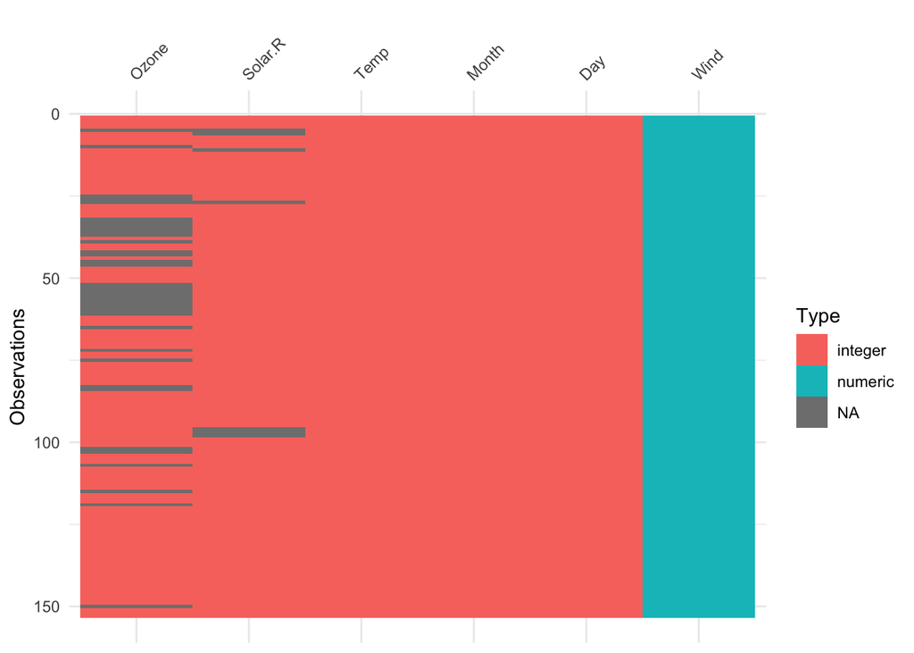

```r
library(tidyverse)
library(dplyr)
library(visdat)
?airquality
vis_dat(airquality)
```

#3. Fit a linear model to the cleaned data to predict Ozone from one of the possible predictors of your choosing. Why did you chose thats variable? #4. Using summary(), Does this seem like a valid model? #Yes, this seems like a valid model because it is evaluating the relationship between ozone and temperature.

```r
cleaned_airquality <- airquality %>%
  drop_na()
model <- lm(Ozone ~ Temp, data = cleaned_airquality)
summary(model)
```

```
Call:
lm(formula = Ozone ~ Temp, data = cleaned_airquality)

Residuals:
    Min      1Q  Median      3Q     Max
-40.922 -17.459  -0.874  10.444 118.078

Coefficients:
             Estimate Std. Error t value Pr(>|t|)
(Intercept) -147.6461    18.7553  -7.872 2.76e-12 ***
Temp           2.4391     0.2393  10.192  < 2e-16 ***
---
Signif. codes:  0 '***' 0.001 '**' 0.01 '*' 0.05 '.' 0.1 ' ' 1

Residual standard error: 23.92 on 109 degrees of freedom
Multiple R-squared:  0.488, Adjusted R-squared:  0.4833
F-statistic: 103.9 on 1 and 109 DF,  p-value: < 2.2e-16
```

#5. Explain the R2 found in a sentence. # The R-squared value is 0.488, therefore 48% of variance in ozone is predictable from the temperature. #6. Use broom::augment to predict the Ozone of the cleaned data

```r
library(broom)
ozone_prediction <- augment(model, new_data = cleaned_airquality)
names(ozone_prediction)
```

```
[1] "Ozone"      "Temp"       ".fitted"    ".resid"     ".hat"
[6] ".sigma"     ".cooksd"    ".std.resid"
```

#7. Use ggplot to plot the actual vs predicted Ozone

#Add a red line to show where the actual and predicted values are equal This can be done by plotting a 1:1 line (e.g. intercept 0, slope 1) with geom_abline(intercept = 0, slope = 1, color = “red”)

#Add a subtitle to the plot showing the correlation between the actual and predicted values are equal This can be done by plotting a 1:1 line (e.g. intercept 0, slope 1) with #paste(“Correlation:”, round(cor(a$Ozone, a$.fitted),2)) assuming your augmented data object is called a

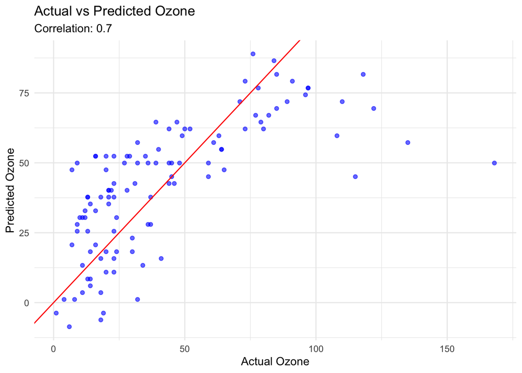

```r
ozone_plot <- ggplot(data = ozone_prediction, aes(x = Ozone, y = .fitted)) +
  geom_point(alpha = 0.6, color = "blue") +
  geom_abline(intercept = 0, slope = 1, color = "red") +
  labs(
    title = "Actual vs Predicted Ozone",
    subtitle = paste("Correlation:", round(cor(ozone_prediction$Ozone, ozone_prediction$.fitted),2)),
       x = "Actual Ozone",
       y = "Predicted Ozone") +
  theme_minimal()
print(ozone_plot)
```